# Линейная регрессия

Линейные модели…

Вадим Хайтов, Анастасия Лянгузова, Наталья Арбузова, Валентина Домашкина, Юта Тамберг, Марина Варфоломеева

Кафедра Зоологии беспозвоночных, СПбГУ

## Мы рассмотрим

- Базовые идеи корреляционного анализа
- Проблему двух статистических подходов: “Тестирование гипотез vs. построение моделей”
- Разнообразие статистических моделей
- Основы регрессионного анализа

### Вы сможете

- Оценить взаимосвязь между измеренными величинами
- Объяснить, что такое линейная модель
- Формализовать запись модели в виде уравнения
- Подобрать модель линейной регрессии
- Протестировать гипотезы о наличии зависимости при помощи t-критерия или F-критерия
- Оценить предсказательную силу модели

## Знакомимся с даными

## Пример: IQ и размеры мозга

Зависит ли уровень интеллекта от размера головного мозга? (Willerman et al. 1991)

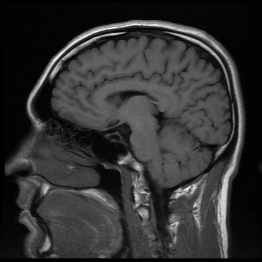

[Scan_03_11](https://flic.kr/p/c45eZ3) by bucaorg(Paul_Burnett) on Flickr

Было исследовано 40 человек: 20 женского и 20 мужского пола.

У каждого индивида измеряли:

- вес,
- рост,
- размер головного мозга (количество пикселей на изображении ЯМР сканера),
- уровень интеллекта (с помощью IQ тестов).

Пример взят из работы: Willerman, L., Schultz, R., Rutledge, J. N., and Bigler, E. (1991), “In Vivo Brain Size and Intelligence,” Intelligence, 15, 223-228.  
Данные представлены в библиотеке *“The Data and Story Library”* http://lib.stat.cmu.edu/DASL/

## Знакомство с данными

Посмотрим на датасет:

```r
brain <- read.csv("data/IQ_brain.csv", header = TRUE)
head(brain)
```

```
  Gender FSIQ VIQ PIQ Weight Height MRINACount
1 Female  133 132 124    118   64.5     816932
2   Male  140 150 124     NA   72.5    1001121
3   Male  139 123 150    143   73.3    1038437
4   Male  133 129 128    172   68.8     965353
5 Female  137 132 134    147   65.0     951545
6 Female   99  90 110    146   69.0     928799
```

Есть ли пропущенные значения?

```r
sum(!complete.cases(brain))
```

```
[1] 2
```

## Где пропущенные значения?

Где именно?

```r
sapply(brain, function(x) sum(is.na(x)))
```

```
    Gender       FSIQ        VIQ        PIQ     Weight     Height MRINACount
         0          0          0          0          2          1          0
```

Что это за случаи?

```r
brain[!complete.cases(brain), ]
```

```
   Gender FSIQ VIQ PIQ Weight Height MRINACount
2    Male  140 150 124     NA   72.5    1001121
21   Male   83  83  86     NA     NA     892420
```

Каков объём выборки?

```r
nrow(brain) ## Это без учета пропущенных значений
```

```
[1] 40
```

## Корреляционный анализ

*Цель практически любого исследования* — поиск взаимосвязи величин и создание базы для предсказания неизвестного на основе имеющихся данных.

## Корреляционный анализ

Наличие связи между явлениями **не означает**, что между ними существует причинно-следственная связь.

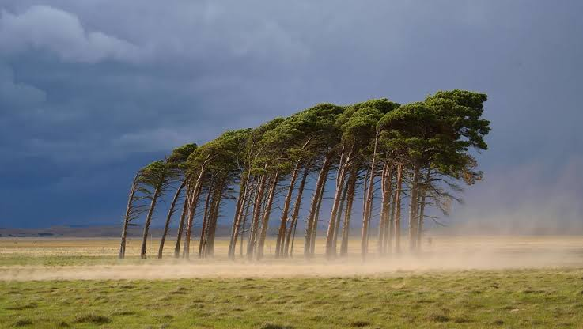

Сила связи между явлениями может быть количественно измерена.

## Основные типы линейной связи между величинами

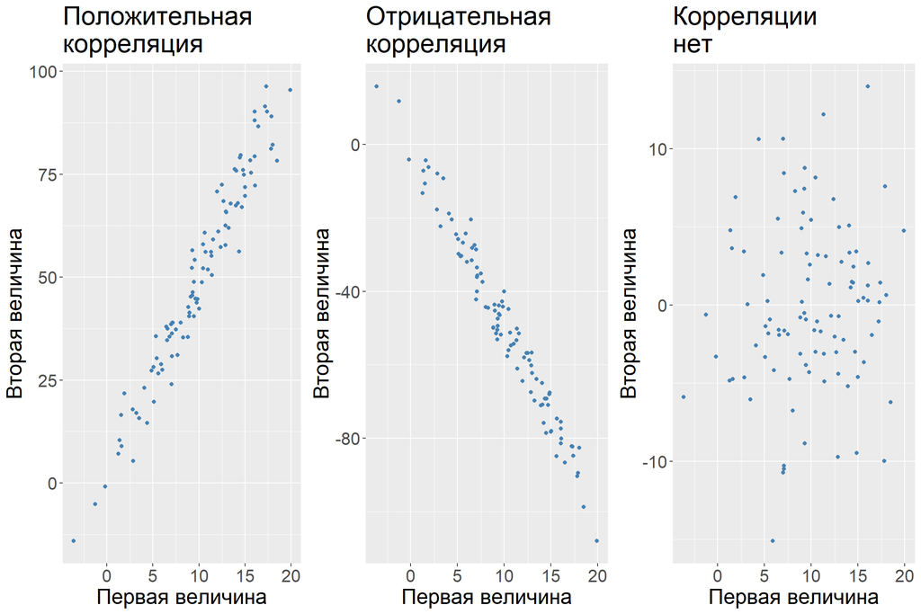

## Криволинейные связи между величинами

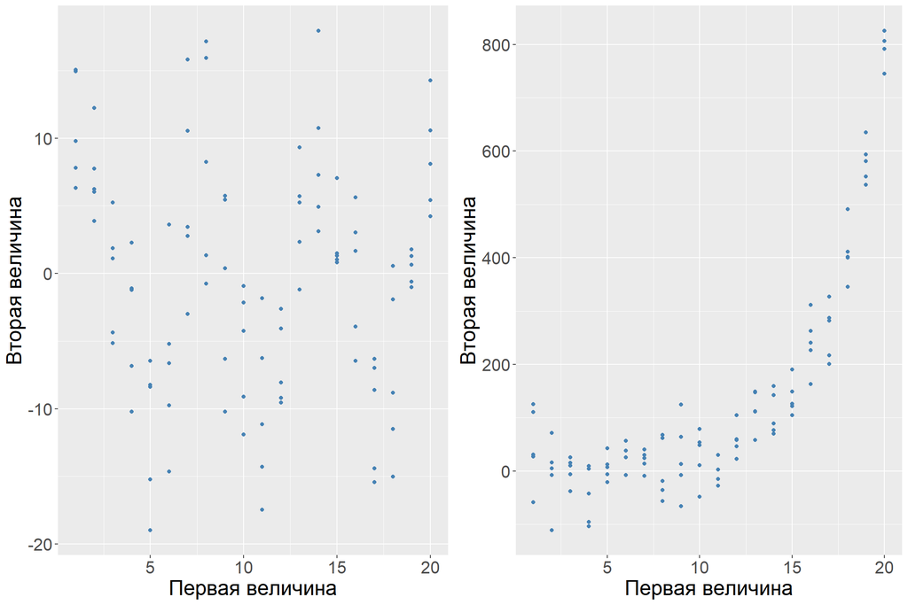

## Коэффициент ковариации

Оценивает **сонаправленность отклонений** двух величин от своих средних значений

$$cov_{x,y} = \frac{\sum(x_i-\bar{x})(y_i-\bar{y})}{n - 1}$$

Коэффициент ковариации варьирует в интервале $-\infty < cov_{x,y} < +\infty$

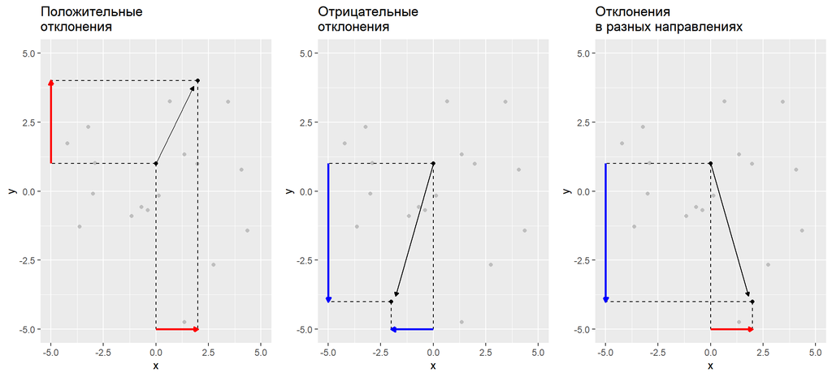

## Коэффициент корреляции

Это стандартизованное значение ковариации:

$$r_{x,y} = \frac{\sum(x_i-\bar{x})(y_i-\bar{y})} {\sqrt{\sum(x_i-\bar{x})^2}\sqrt{\sum(y_i-\bar{y})^2}} = \frac{cov_{x,y}} {\sigma_x \sigma_y}$$

Коэффициент корреляции варьирует в интервале: $-1 \le r_{x,y} \le +1$

## Коэффициент корреляции - это еще и параметр двумерного нормального распределения

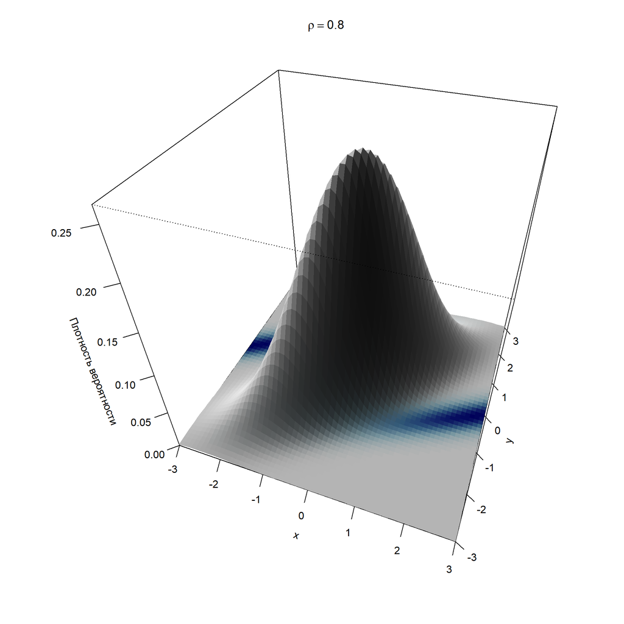

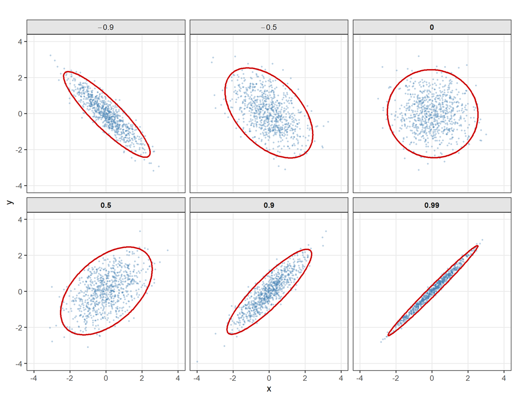

## Коэффициенты корреляции и условия их применимости

| Коэффициент | Функция | Особенности применения |
| --- | --- | --- |
| Коэффициент Пирсона | `cor(x,y,method="pearson")` | Оценивает связь двух нормально распределенных величин. Выявляет только линейную составляющую взаимосвязи. |
| Ранговые коэффициенты (коэффициент Спирмена, Кендалла) | `cor(x,y,method="spearman")` `cor(x,y,method="kendall")` | Не зависят от формы распределения. Могут оценивать связь для любых монотонных зависимостей. |

## Оценка статистической значимости коэффициентов корреляции

- Коэффициент корреляции — это статистика, значение которой описывает степень взаимосвязи двух сопряженных переменных. Следовательно, применима логика статистического критерия.
- Нулевая гипотеза $H_0: r=0$.
- Бывают двусторонние $H_a: r\ne 0$ и односторонние критерии $H_a: r>0$ или $H_a: r<0$.
- Ошибка коэффициента Пирсона: $SE_r=\sqrt{\frac{1-r^2}{n-2}}$.
- Стандартизованная величина $t=\frac{r}{SE_r}$ подчиняется распределению Стьюдента с параметром $df = n-2$.
- Для ранговых коэффициентов существует проблема “совпадающих рангов” (tied ranks), что приводит к приблизительной оценке $r$ и приблизительной оценке уровня значимости.
- Значимость коэффициента корреляции можно оценить пермутационным методом.

## Задание

- Постройте точечную диаграмму, отражающую взаимосвязь между результатами IQ-теста (PIQ) и размером головного мозга (MRINACount)
- Определите силу и направление связи между этими величинами
- Оцените сатистическую значимость коэффициента корреляции Пирсона между этими двумя переменными
- Придумайте способ, как оценить корреляцию между всеми парами исследованных признаков

*Hint 1*: Обратите внимание на то, что в датафрейме есть пропущенные значения. Изучите, как работают с `NA` функции, вычисляющие коэффициенты корреляции.

## Решение

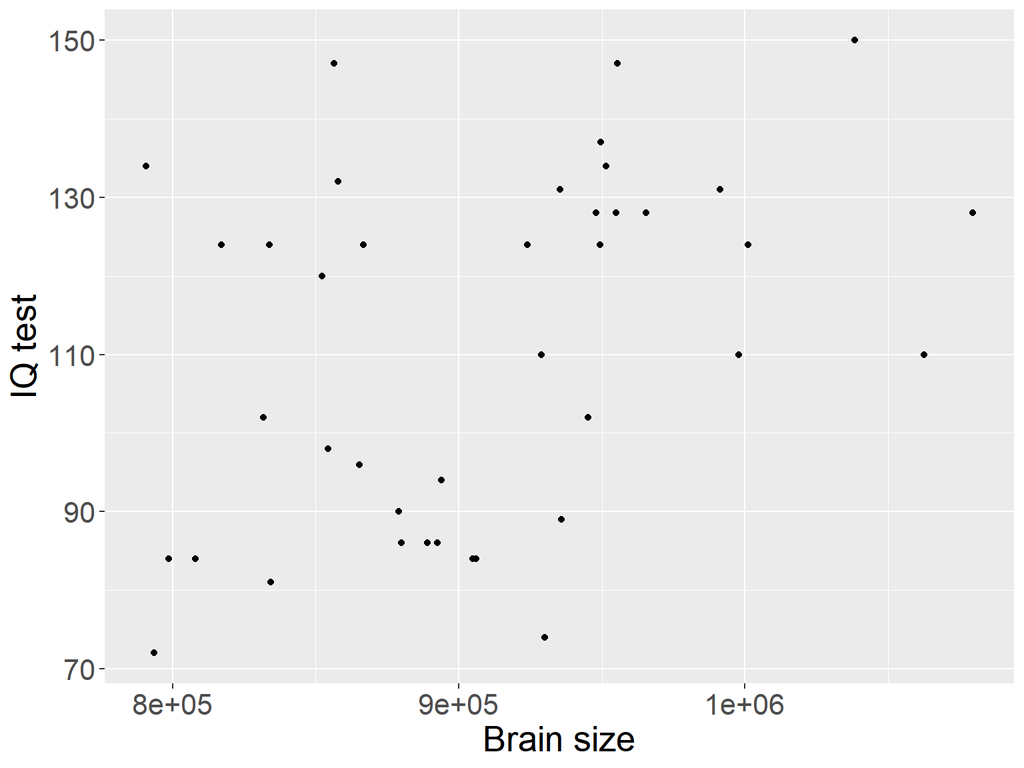

```r
pl_brain <- ggplot(brain,
               aes(x = MRINACount, y = PIQ)) +
  geom_point() +
  xlab("Brain size") +
  ylab("IQ test") +
  theme(text = element_text(size = 20))
pl_brain
```

## Решение

```r
cor.test(brain$PIQ, brain$MRINACount, method = "pearson", alternative = "two.sided")
```

```
    Pearson's product-moment correlation

data:  brain$PIQ and brain$MRINACount
t = 2.5858, df = 38, p-value = 0.01367
alternative hypothesis: true correlation is not equal to 0
95 percent confidence interval:
 0.08562561 0.62322928
sample estimates:
      cor
0.3868173
```

## Решение

```r
cor(brain[, 2:6], use = "pairwise.complete.obs")
```

```
              FSIQ         VIQ          PIQ       Weight      Height
FSIQ    1.00000000  0.94663878  0.934125147 -0.051482850 -0.08600241
VIQ     0.94663878  1.00000000  0.778135114 -0.076088042 -0.07106813
PIQ     0.93412515  0.77813511  1.000000000  0.002512154 -0.07672318
Weight -0.05148285 -0.07608804  0.002512154  1.000000000  0.69961400
Height -0.08600241 -0.07106813 -0.076723176  0.699614004  1.00000000
```

## Два подхода к исследованию: Тестирование гипотезы VS Построение модели

- Проведя корреляционный анализ, мы лишь ответили на вопрос “Существует ли статистически значимая связь между величинами?”
- Сможем ли мы, используя это знание, *предсказать* значения одной величины, исходя из знаний другой?

## Тестирование гипотезы VS построение модели

Простейший пример:

- Между путем, пройденным автомобилем, и временем, проведенным в движении, несомненно есть связь. Хватает ли нам этого знания?
- Для расчета величины пути в зависимости от времени необходимо построить модель: $S=Vt$, где $S$ — зависимая величина, $t$ — независимая переменная, $V$ — параметр модели.
- Зная параметр модели (скорость) и значение независимой переменной (время), мы можем рассчитать (*cмоделировать*) величину пройденного пути.

## Какие бывают модели?

## Линейные и нелинейные модели

Линейные модели

$$y = b_0 + b_1x$$

$$y = b_0 + b_1x_1 + b_2x_2$$

Нелинейные модели

$$y = b_0 + b_1^x$$

$$y = b_0^{b_1x_1+b_2x_2}$$

## Простые и многокомпонентные (множественные) модели

- Простая модель
  $$y = b_0 + b_1x$$
- Множественная модель
  $$y = b_0 + b_1x_1 + b_2x_2 + b_3x_3 + ... + b_nx_n$$

## Детерминистские и стохастические модели

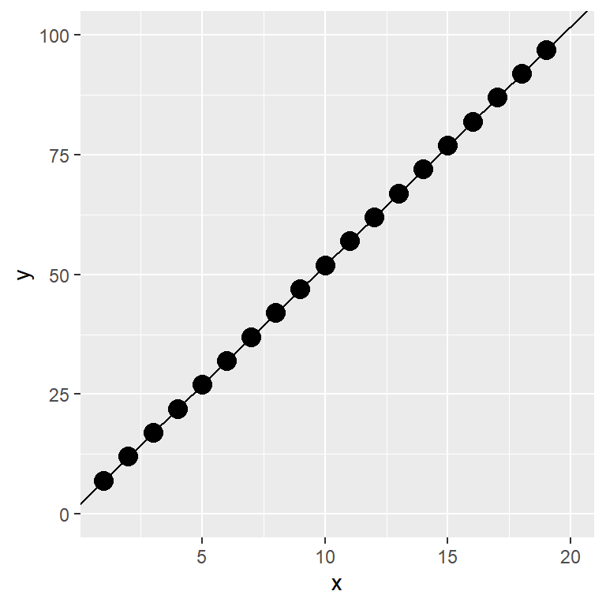

Модель: $у_i = 2 + 5x_i$

Два параметра:

угловой коэффициент (slope) $b_1=5$;

свободный член (intercept) $b_0=2$.

Чему равен $y$ при $x=10$?

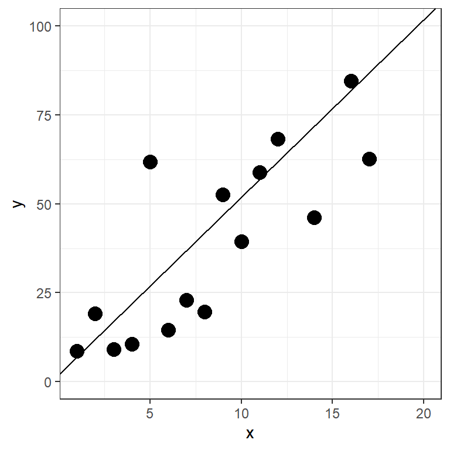

Модель: $у_i = 2 + 5x_i + \varepsilon_i$

Появляется дополнительный член $\varepsilon_i$. Он вводит в модель влияние неучтенных моделью факторов.

Обычно считают, что $\epsilon \in N(0, \sigma^2)$.

## Случайная и фиксированая часть модели

В стохастические модели выделяется две части:

**Фиксированная часть:** $у_i = 2 + 5x_i$  
**Случайная часть:** $\varepsilon_i$

Бывают модели, в которых случайная часть выглядит существенно сложнее (модели со смешанными эффектами). В таких моделях необходимо смоделировать еще и поведение случайной части.

## Модель для зависимости величины IQ от размера головного мозга

Какая из линий “лучше” описывает облако точек?

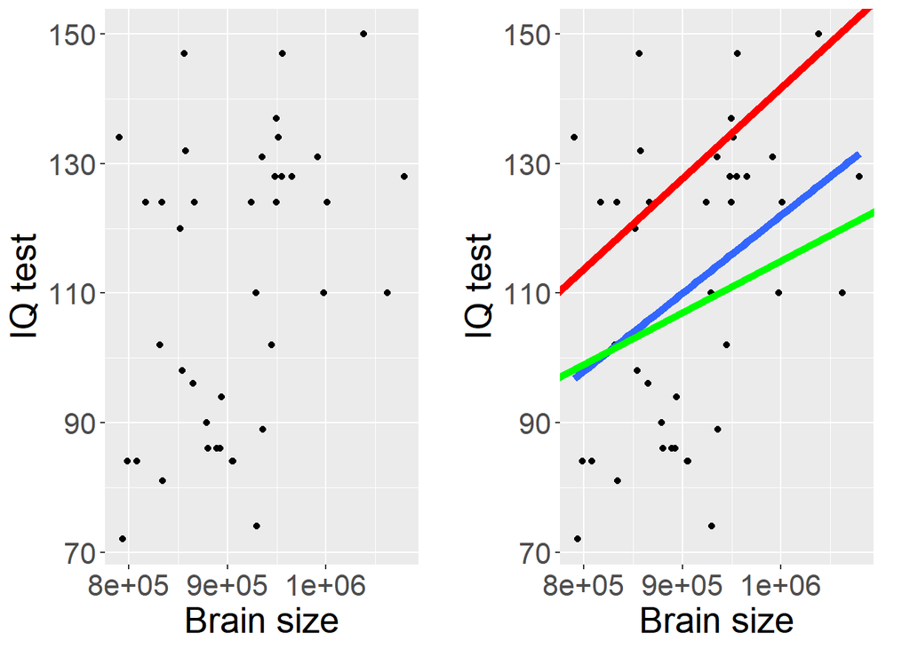

## Найти оптимальную модель позволяет регрессионный анализ

“Essentially, all models are wrong, but some are useful”

(George E. P. Box)

## Происхождение термина “регрессия”

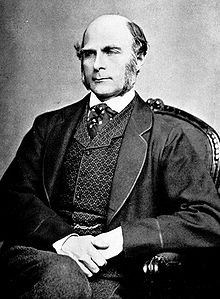

Френсис Галтон (Francis Galton)

“the Stature of the adult offspring … [is] … more mediocre than the stature of their Parents” (цит. по `Legendre & Legendre, 1998`)

Рост *регрессирует* (возвращается) к популяционной средней.

Угловой коэффициент в зависимости роста потомков от роста родителей — *коэффициент регрессии*.

## Подбор линии регрессии проводится с помощью двух методов

> - С помощью метода наименьших квадратов (Ordinary Least Squares) — используется для простых линейных моделей.
> - Через подбор функции максимального правдоподобия (Maximum Likelihood) — используется для подгонки сложных линейных и нелинейных моделей.

## Метод наименьших квадратов

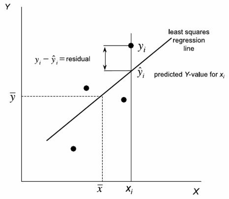

(из кн. Quinn, Keough, 2002, стр. 85)

Остатки (Residuals):
$$\varepsilon_i = y_i - \hat{y_i}$$

Линия регрессии (подобранная модель) — это та линия, у которой $\sum{\varepsilon_i}^2$ минимальна.

## Подбор модели методом наименьших квадратов с помощью функци `lm()`

`fit <- lm(formula, data)`

Модель записывается в виде **двусторонней** формулы:

| Модель | Формула |
| --- | --- |
| Простая линейная регрессия $\hat{y_i}=b_0 + b_1x_i$ | `Y ~ X` `Y ~ 1 + X` `Y ~ X + 1` |
| Простая линейная регрессия (без $b_0$, “no intercept”) $\hat{y_i}=b_1x_i$ | `Y ~ -1 + X` `Y ~ X - 1` |
| Уменьшенная простая линейная регрессия $\hat{y_i}=b_0$ | `Y ~ 1` `Y ~ 1 - X` |
| Множественная линейная регрессия $\hat{y_i}=b_0 + b_1x_i +b_2x_2$ | `Y ~ X1 + X2` |

## Подбор модели методом наименьших квадратов с помощью функци `lm()`

`fit <- lm(formula, data)`

Элементы формул для записи множественных моделей

| Элемент формулы | Значение |
| --- | --- |
| `:` | Взаимодействие предикторов `Y ~ X1 + X2 + X1:X2` |
| `*` | Обозначает полную схему взаимодействий `Y ~ X1 * X2 * X3` аналогично `Y ~ X1 + X2 + X3+ X1:X2 + X1:X3 + X2:X3 + X1:X2:X3` |
| `.` | `Y ~ .` В правой части формулы записываются все переменные из датафрейма, кроме `Y` |

## Подберем модель, наилучшим образом описывающую зависимость результатов IQ-теста от размера головного мозга

```r
brain_model <- lm(PIQ ~ MRINACount, data = brain)
brain_model
```

```
Call:
lm(formula = PIQ ~ MRINACount, data = brain)

Coefficients:
(Intercept)   MRINACount
  1.7437570    0.0001203
```

## Как трактовать значения параметров регрессионной модели?

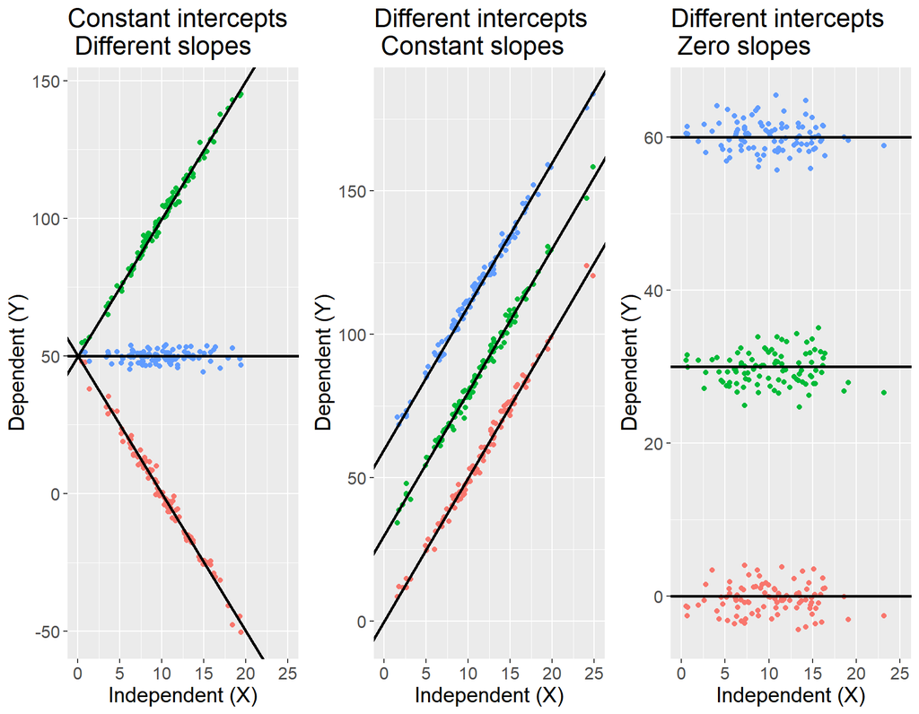

## Как трактовать значения параметров регрессионной модели?

> - **Угловой коэффициент** (*slope*) показывает *на сколько* *единиц* изменяется предсказанное значение $\hat{y}$ при изменении на *одну единицу* значения предиктора $(x)$.
> - **Свободный член** (*intercept*) — величина во многих случаях не имеющая “смысла”, просто поправочный коэффициент, без которого нельзя вычислить $\hat{y}$.  
>   *NB!* В некоторых линейных моделях он имеет смысл, например, значения $\hat{y}$ при $x = 0$.
> - **Остатки** (*residuals*) характеризуют влияние неучтенных моделью факторов.

## Вопросы:

1. Чему равны угловой коэффициент и свободный член полученной модели `brain_model`?
2. Какое значение IQ-теста предсказывает модель для человека с объемом мозга равным 900000?
3. Чему равно значение остатка от модели для человека с порядковым номером 10?

## Ответы

1. Чему равны угловой коэффициент и свободный член полученной модели `brain_model`?

```r
coefficients(brain_model) [1]
```

```
(Intercept)
   1.743757
```

```r
coefficients(brain_model) [2]
```

```
  MRINACount
0.0001202538
```

## Ответы

Какое значение IQ-теста предсказывает модель для человека с объемом мозга равным 900000?

```r
as.numeric(coefficients(brain_model) [1] + coefficients(brain_model) [2] * 900000)
```

```
[1] 109.9722
```

## Ответы

3. Чему равно значение остатка от модели для человека с порядковым номером 10?

```r
brain$PIQ[10] - fitted(brain_model)[10]
```

```
      10
30.35782
```

```r
residuals(brain_model)[10]
```

```
      10
30.35782
```

## Углубляемся в анализ модели: функция `summary()`

```r
summary(brain_model)
```

```
Call:
lm(formula = PIQ ~ MRINACount, data = brain)

Residuals:
    Min      1Q  Median      3Q     Max
-39.582 -17.953  -1.601  17.027  42.262

Coefficients:
             Estimate Std. Error t value Pr(>|t|)
(Intercept) 1.744e+00  4.239e+01   0.041   0.9674
MRINACount  1.202e-04  4.651e-05   2.586   0.0137 *
---
Signif. codes:  0 '***' 0.001 '**' 0.01 '*' 0.05 '.' 0.1 ' ' 1

Residual standard error: 20.99 on 38 degrees of freedom
Multiple R-squared:  0.1496,    Adjusted R-squared:  0.1272
F-statistic: 6.686 on 1 and 38 DF,  p-value: 0.01367
```

## Что означают следующие величины?

`Estimate`  
`Std. Error`  
`t value`  
`Pr(>|t|)`

## Оценки параметров регрессионной модели

[output not shown]

Где $MS_e$ — Mean Sum of Squares — $\frac{SS_e}{df_e}$.

## Для чего нужны стандартные ошибки?

- Они нужны, поскольку мы *оцениваем* параметры по *выборке*;
- Позволяют построить доверительные интервалы для параметров;
- Их используют в статистических тестах.

```
Call:
lm(formula = PIQ ~ MRINACount, data = brain)

Residuals:
    Min      1Q  Median      3Q     Max
-39.582 -17.953  -1.601  17.027  42.262

Coefficients:
             Estimate Std. Error t value Pr(>|t|)
(Intercept) 1.744e+00  4.239e+01   0.041   0.9674
MRINACount  1.202e-04  4.651e-05   2.586   0.0137 *
---
Signif. codes:  0 '***' 0.001 '**' 0.01 '*' 0.05 '.' 0.1 ' ' 1

Residual standard error: 20.99 on 38 degrees of freedom
Multiple R-squared:  0.1496,    Adjusted R-squared:  0.1272
F-statistic: 6.686 on 1 and 38 DF,  p-value: 0.01367
```

## Графическое представление результатов

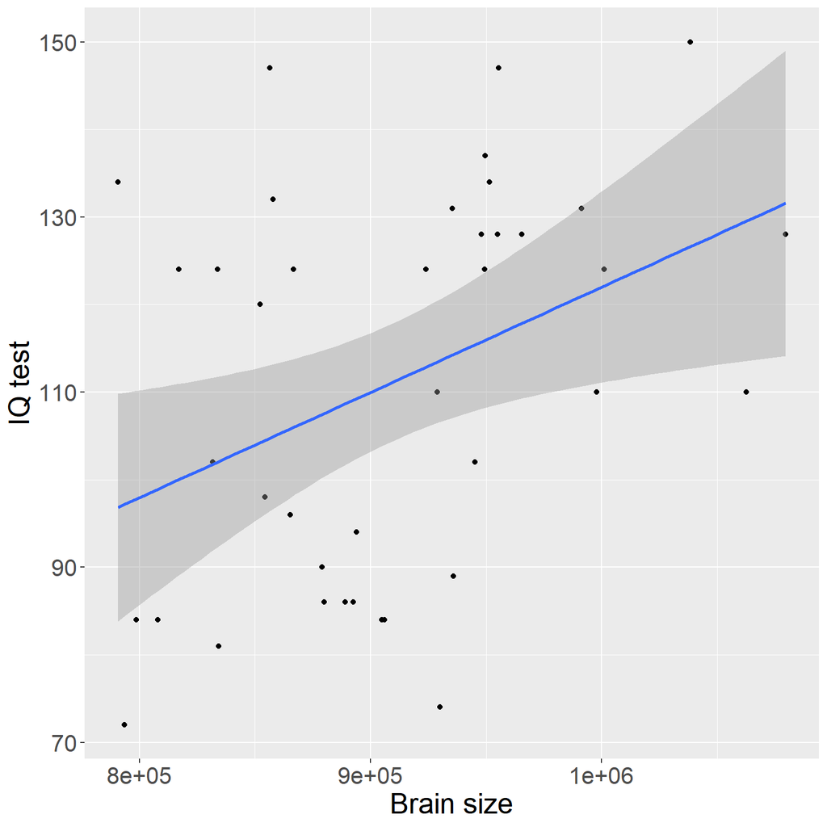

```r
pl_brain + geom_smooth(method="lm")
```

**Доверительная зона регрессии**. В ней с 95% вероятностью лежит регрессионная прямая, описывающая связь в генеральной совокупности.

Возникает из-за неопределенности оценок коэффициентов модели, вследствие выборочного характера оценок.

## Зависимость в генеральной совокупности

Симулированный пример: Генеральная совокупность, в которой связь между Y и X, описывается следующей зависимостью

$$y_i = 10 + 10x_i + \varepsilon_i \\
\varepsilon \in N(0, 20)$$

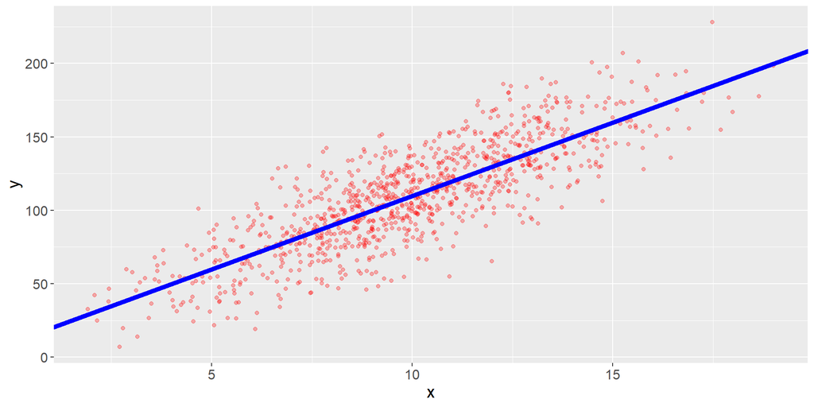

```r
pop_x <- rnorm(1000, 10, 3)
pop_y <- 10 + 10 * pop_x + rnorm(1000, 0, 20)
population <- data.frame(x = pop_x, y = pop_y)

pop_plot <- ggplot(population, aes(x = x, y = y)) +
  geom_point(alpha = 0.3, color = "red") +
  geom_abline(aes(intercept = 10, slope = 10),
              color = "blue", size = 2) +
  theme(text = element_text(size = 15))
pop_plot
```

## Зависимости, выявленные в нескольких разных выборках

Линии регрессии, полученные для 100 выборок (по 20 объектов в каждой), взятых из одной и той же генеральной совокупности.

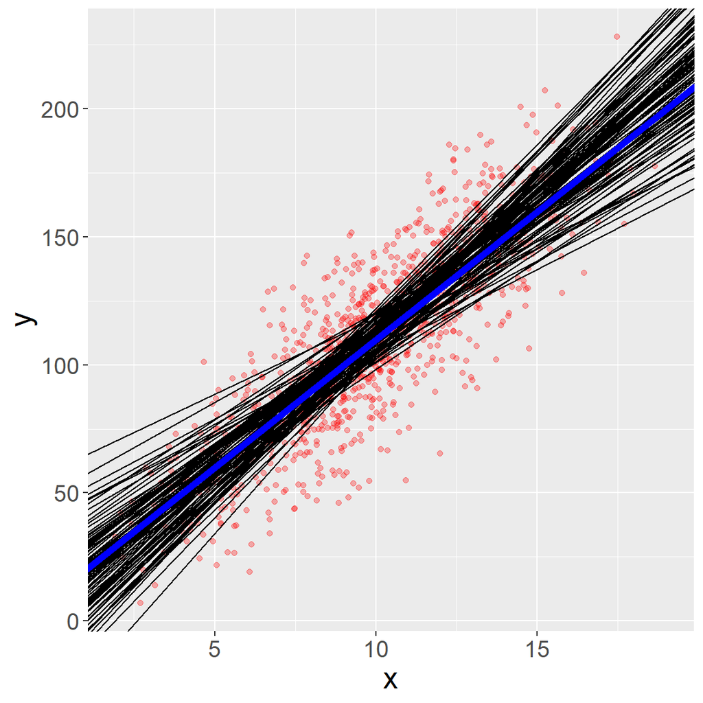

```r
samp_coef <- data.frame(b0 = rep(NA, 100), b1 =  rep(NA, 100))

for(i in 1:100) {
  samp_num <- sample(1:1000, 20)
  samp <- population[samp_num, ]
  fit <- lm(y ~ x, data = samp)
  samp_coef$b0[i] <- coef(fit)[1]
  samp_coef$b1[i] <- coef(fit)[2]
}

ggplot(population, aes(x = x, y = y)) + geom_point(alpha = 0.3, color = "red")+ geom_abline(aes(intercept = b0, slope = b1), data = samp_coef) + geom_abline(aes(intercept = 10, slope = 10), color = "blue", size = 2) +
  theme(text = element_text(size = 18))
```

## Доверительные интервалы для коэффициентов уравнения регрессии

```r
coef(brain_model)
```

```
 (Intercept)   MRINACount
1.7437570401 0.0001202538
```

```r
confint(brain_model)
```

```
                    2.5 %       97.5 %
(Intercept) -8.407513e+01 8.756265e+01
MRINACount   2.610804e-05 2.143996e-04
```

## Для разных $\alpha$ можно построить разные доверительные интервалы

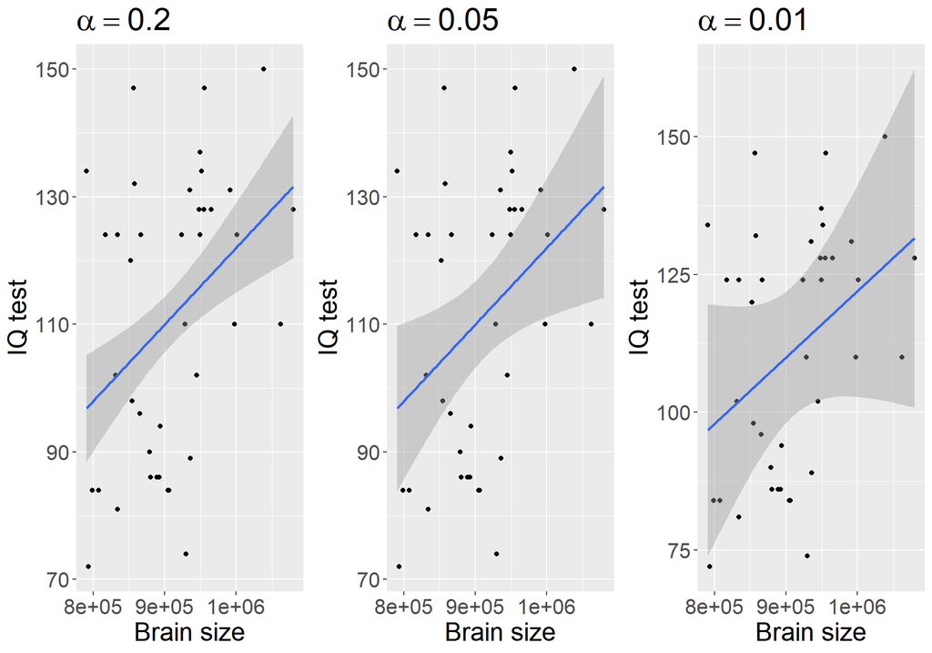

## Важно!

Если коэффициенты уравнения регрессии — лишь приблизительные оценки параметров, то предсказать значения зависимой переменной можно только *с нeкоторой вероятностью*.

## Какое значение IQ можно ожидать у человека с размером головного мозга 900000?

```r
newdata <- data.frame(MRINACount = 9e+05)

predict(brain_model, newdata, interval = "prediction", level = 0.95, se = TRUE)$fit
```

```
       fit      lwr      upr
1 109.9722 66.93883 153.0055
```

## Отражаем на графике область значений, в которую попадут 95% предсказанных величин IQ

Подготавливаем данные:

```r
brain_predicted <- predict(brain_model, interval="prediction")
brain_predicted <- data.frame(brain, brain_predicted)
head(brain_predicted)
```

```
  Gender FSIQ VIQ PIQ Weight Height MRINACount       fit      lwr      upr
1 Female  133 132 124    118   64.5     816932  99.98294 56.09762 143.8683
2   Male  140 150 124     NA   72.5    1001121 122.13236 78.23695 166.0278
3   Male  139 123 150    143   73.3    1038437 126.61975 81.89560 171.3439
4   Male  133 129 128    172   68.8     965353 117.83112 74.47698 161.1853
5 Female  137 132 134    147   65.0     951545 116.17066 72.95702 159.3843
6 Female   99  90 110    146   69.0     928799 113.43537 70.36855 156.5022
```

## Отражаем на графике область значений, в которую попадут 95% предсказанных величин IQ

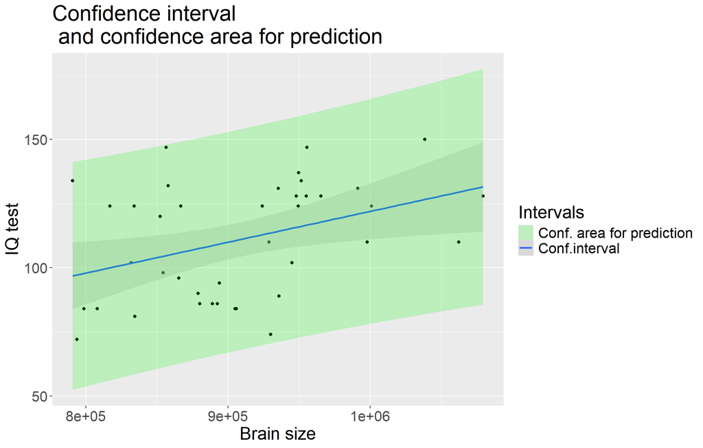

## Код для построения графика

```r
pl_brain +

# 1) Линия регрессии и ее дов. интервал
# Если мы указываем fill внутри aes() и задаем фиксированное значение -
#  появится соотв. легенда с названием.
# alpha - задает прозрачность
  geom_smooth(method = "lm", aes(fill = "Conf.interval"), alpha = 0.4) +
# 2) Интервал предсказаний создаем при помощи геома ribbon ("лента")
# Данные берем из другого датафрейма - из brain_predicted
# ymin и ymax - эстетики геома ribbon, которые задают нижний и верхний
# край ленты в точках с заданным x (x = MRINACount было задано в ggplot()
# при создании pl_brain, поэтому сейчас его указывать не обязательно)
#

geom_ribbon(data = brain_predicted,  aes(ymin = lwr, ymax = upr, fill = "Conf. area for prediction"), alpha = 0.2) +
# 3) Вручную настраиваем цвета заливки при помощи шкалы fill_manual.
# Ее аргумент name - название соотв. легенды, values - вектор цветов
  scale_fill_manual(name = "Intervals", values = c("green", "gray")) +
# 4) Название графика
  ggtitle("Confidence interval \n and confidence area for prediction")
```

## Важно!

Модель “работает” только в том диапазоне значений независимой переменной $(x)$, для которой она построена (интерполяция).

Экстраполяцию надо применять с большой осторожностью.

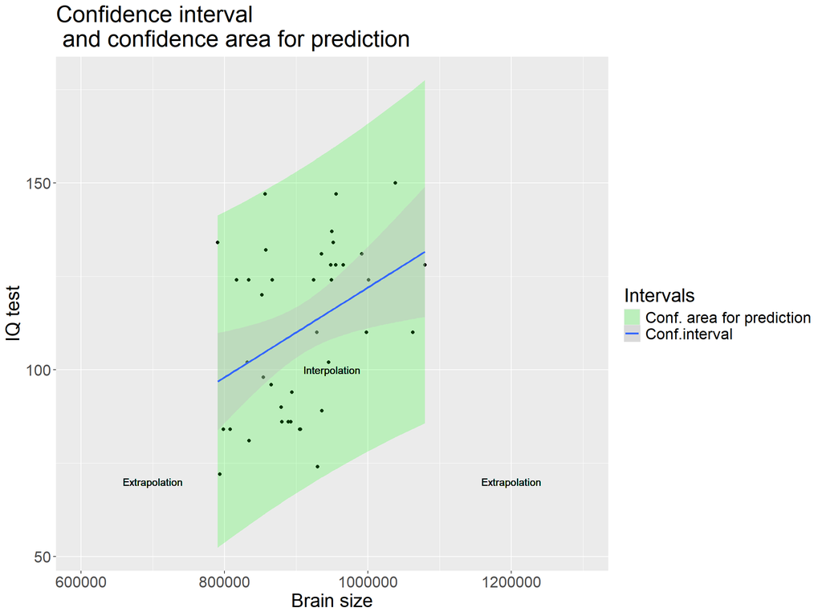

## Итак, что означают следующие величины?

> - `Estimate`
> - Оценки праметров регрессионной модели
> - `Std. Error`
> - Стандартная ошибка для оценок
> - Осталось решить, что такое `t value`, `Pr(>|t|)`

## Summary

> - Модель простой линейной регрессии $y _i = \beta _0 + \beta _1 x _i + \epsilon _i$
> - Параметры модели оцениваются на основе выборки
> - В оценке коэффициентов регрессии и предсказанных значений существует неопределенность: необходимо вычислять доверительный интервал.
> - Доверительные интервалы можно расчитать, зная стандартные ошибки.

## Что почитать

- Гланц, С., 1998. Медико-биологическая статистика. М., Практика
- Кабаков Р.И. R в действии. Анализ и визуализация данных на языке R. М.: ДМК Пресс, 2014
- Diez, D.M., Barr, C.D. and Çetinkaya-Rundel, M., 2015. OpenIntro Statistics. OpenIntro.
- Zuur, A., Ieno, E.N. and Smith, G.M., 2007. Analyzing ecological data. Springer Science & Business Media.
- Quinn G.P., Keough M.J. 2002. Experimental design and data analysis for biologists
- Logan M. 2010. Biostatistical Design and Analysis Using R. A Practical Guide